# Length Based Spawning Potential Ratio (LB-SPR)

Aplicación al stock costero de Galicia de Trisopterus luscus

A. Alonso-Fernández; J. Otero

Octubre de 2020

# 1 Introduction

## 1.1 What is Spawning Potential ratio (SPR)?

- Spawning Potential ratio (SPR) is defined as the proportion of Spawning Biomass per recruit (SBPR) in an exploited stock with regards to SBPR in an unfished (virgin) stock.
- The rationale behind is that the abundance at length in the population decreases with ageing (length) because of the mortality (M and F).
- A virgin population will have a larger amount of large mature individuals than an exploited population.
- The SPR ranges between 1 (virgin population) and 0.
- A SPR in the Range of 0.35-0.4 are ususaly considered a population at MSY level although this is a quite variable parameter.
- A population with SPR below 0.1-0.15 are considered collapsed.

## 1.2 LBSPR Modes

LBSPR package contains functions to run the Length-Based Spawning Potential Ratio (LBSPR) method. The LBSPR package can be used in two ways:

- **Simulating** the expected length composition, growth curve, and SPR and yield curves using the LBSPR model and
- **Fitting** to empirical length data to provide an estimate of the spawning potential ratio (SPR).

## 1.3 LBSPR data needed

The LBSPR method has been developed for data-limited fisheries, Data requested are:

- A representative sample of the **size structure of the catch**.
- An understanding of the **life history** of the species.

The LBSPR method does not require knowledge of the natural mortality rate (*M*), but instead uses the ratio of natural mortality and the von Bertalanffy growth coefficient (*K*) (*M*/*K*), which is believed to vary less across stocks and species than *M* (Prince et al. 2015).

## 1.4 LBSPR Assumptions

LBSPR model relies on a number of simplifying **assumptions**:

- The LBSPR models are equilibrium based.
- The length composition data is representative of the exploited population at steady state. Whith logistic selection.

See the publications listed in the reference list for full details of the assumptions of the model, including simulation testing to evauate the effect of violations of these assumptions.

## 1.5 SPR versions

### 1.5.1 Age-Structured Length-Based Model

The LBSPR model described by Hordyk et al. (2015a, b), and tested in a MSE framework (Hordyk et al. 2015c), use a conventional age-structured equilibrium population model. An important assumption of this model structure is that selectivity is age-based not length-based.

### 1.5.2 Length-Structured Growth-Type-Group Model

Hordyk et al. (2016) describe a length-structured version of the LBSPR model that uses growth-type-groups (GTG) to account for size-based selectivity. The GTG-LBSPR model also has the ability to include variable *M* at size (by default *M* is assumed to be constant). The GTG-LBSPR model typically estimates a lower fishing mortality rate for a given size structure compared to the earlier age-structured model. This is because the age-structured model has a ‘regeneration assumption’, where, because of the age-based selectivity assumption, large individuals are expected even at high fishing mortality (large, young fish).

The default setting for the LBSPR package is to use the GTG-LBSPR model for all simulation and estimation. Control options in the simulation and estimation functions can be used to switch to the age-structured LBSPR model.

Please make sure you understand the data and the biological parameters (and how the model treats these) and critically evaluate any output of the LBSPR model.

## 1.6 Installing and loading the Package

The LBSPR package is now available on CRAN:

You can install the development version of the package from GitHub using the `devtools` package:

Load the Package

# 2 Fitting *Trisopteurs luscus* from Galician coast

We are going to use data of *Trisopterus luscus* from the observer monitoring programm of the **UTPB** (Xunta de Galicia). The data were recorded onboard small-scale fishing vessels working on shallow waters (up to 150 m depth) along the Galician coast since 1999. We choose data only from boats using **VETAS** fishing gear, as the most representative for this species (see Alonso-Fernández et al. 2019.

*Trisopterus luscus* life history traits (LHT).

- MAturity oogive of females from Alonso-Fernandez et al. (2008), $L^{LIT}_{50} = 19.2 cm$, based on histology.
- Growth parameters (Von Bertalanffy) based on Labarta et al. (1982): $L^{LIT}_{inf} = 46.7 cm$; $K^{LIT} = 0.21$; $t^{LIT}_{0} = 1.27$; $A^{LIT}_{max} = 9 years$.
- Estimates $M/K^{LIT}$ from Then et al. (2015). As reference we will usenatural moratlity estimates using growth parameters: $M_{VBGF} = 0.3699877 y^{-1}$; $M_{VBGF}/K^{LIT} = 1.761846$. But also we will try longevity: $M_{nls} = 0.6533320 y^{-1}$; $M_{nls}/K^{LIT} = 3.111105$. We used app [Barefoot Ecologist’s Toolbox](http://barefootecologist.com.au/shiny_m).

```
##  [1] "Species"      "MK"           "M"            "Linf"
##  [5] "L_units"      "CVLinf"       "L50"          "L95"
##  [9] "Walpha"       "Walpha_units" "Wbeta"        "FecB"
## [13] "Steepness"    "Mpow"         "R0"           "SL50"
## [17] "SL95"         "MLL"          "sdLegal"      "fDisc"
## [21] "FM"           "SPR"          "BinMin"       "BinMax"
## [25] "BinWidth"
```

```
## Length bin parameters (BinMax) must be set for raw data. Using defaults
```

```
## Length bin parameters (BinMin) must be set for raw data. Using defaults
```

```
## Length bin parameters (BinWidth) must be set for raw data. Using defaults
```

## 2.1 LB-SPR model

Plotting length distribution fit.

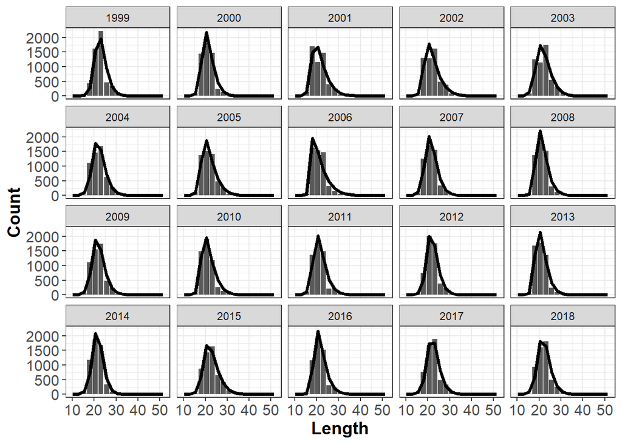

Plotting yearly selectivity and maturity.

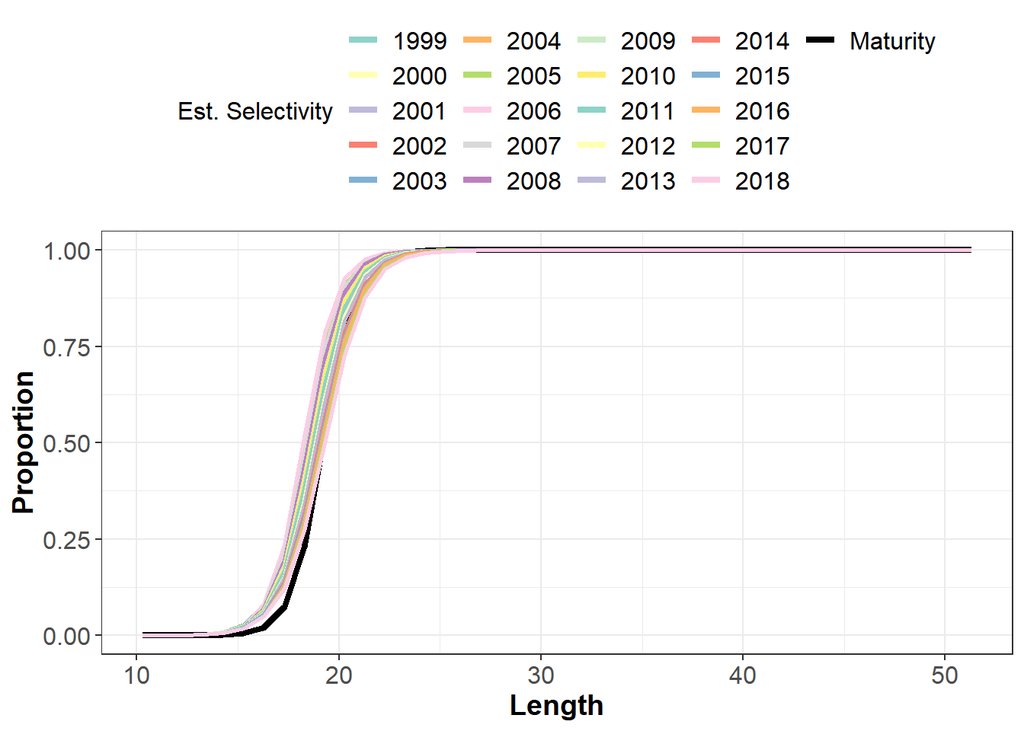

Plotting yearly selectivity, F/M and SPR

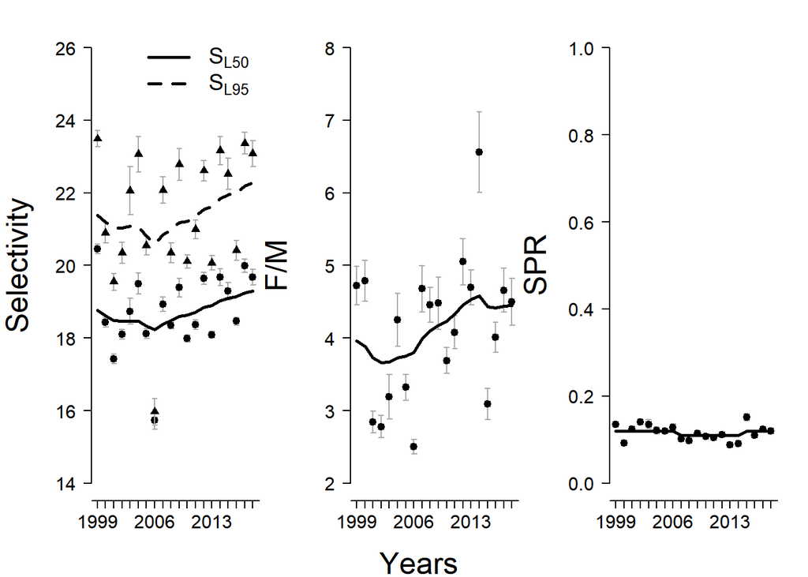

**Tabla 2.** Summary table of LB-SRP model fit to *Trisopterus luscus* length data.

| Year | SL50 | SL95 | FM | SPR |
| --- | --- | --- | --- | --- |
| 1999 | 20.45 | 23.49 | 4.72 | 0.13 |
| 2000 | 18.44 | 20.90 | 4.79 | 0.09 |
| 2001 | 17.43 | 19.55 | 2.84 | 0.12 |
| 2002 | 18.11 | 20.35 | 2.78 | 0.14 |
| 2003 | 18.74 | 22.06 | 3.19 | 0.14 |
| 2004 | 19.50 | 23.06 | 4.25 | 0.12 |
| 2005 | 18.12 | 20.55 | 3.32 | 0.12 |
| 2006 | 15.73 | 15.97 | 2.50 | 0.13 |
| 2007 | 18.93 | 22.08 | 4.68 | 0.1 |
| 2008 | 18.36 | 20.35 | 4.46 | 0.1 |
| 2009 | 19.39 | 22.78 | 4.48 | 0.11 |
| 2010 | 17.99 | 20.11 | 3.69 | 0.11 |
| 2011 | 18.37 | 20.99 | 4.08 | 0.1 |
| 2012 | 19.65 | 22.61 | 5.05 | 0.11 |
| 2013 | 18.09 | 20.07 | 4.70 | 0.09 |
| 2014 | 19.68 | 23.16 | 6.56 | 0.09 |
| 2015 | 19.29 | 22.52 | 3.09 | 0.15 |
| 2016 | 18.46 | 20.41 | 4.01 | 0.11 |
| 2017 | 19.99 | 23.37 | 4.66 | 0.12 |
| 2018 | 19.68 | 23.08 | 4.50 | 0.12 |

## 2.2 Sensitivity analysis

We change values of $L_{inf}$ and $M/K$ to evaluate effect os LBSPR results.

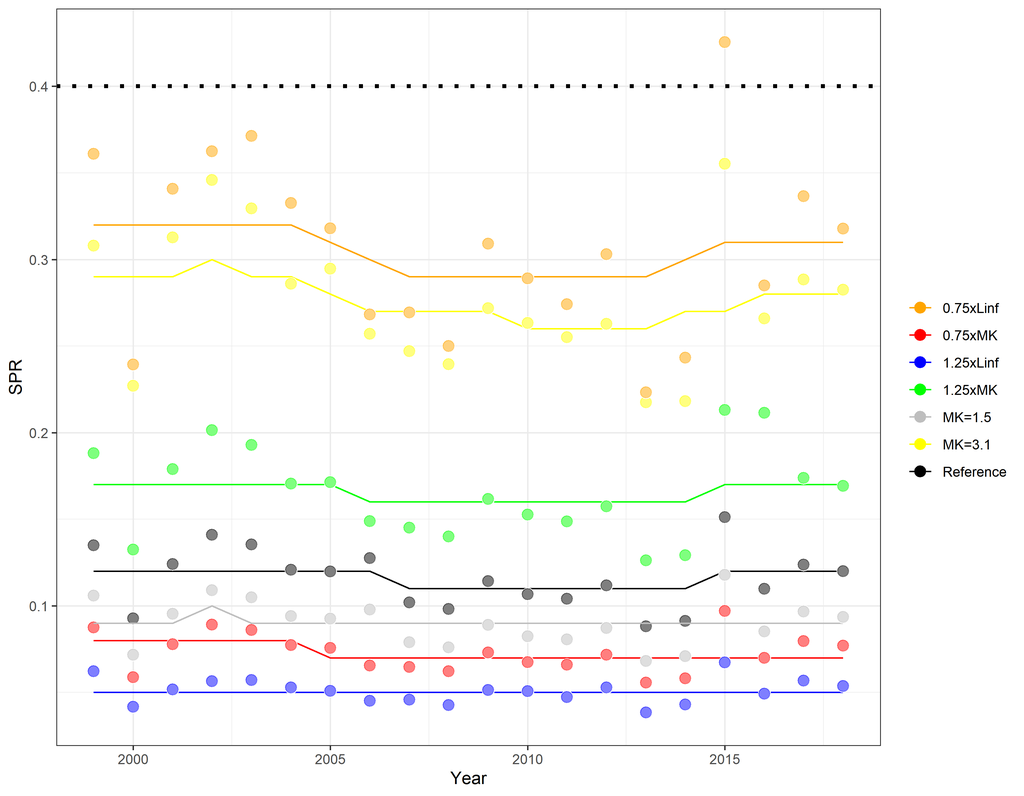

Figure 1. SPR estimates for each of the scenarios of the sensitivity analysis.

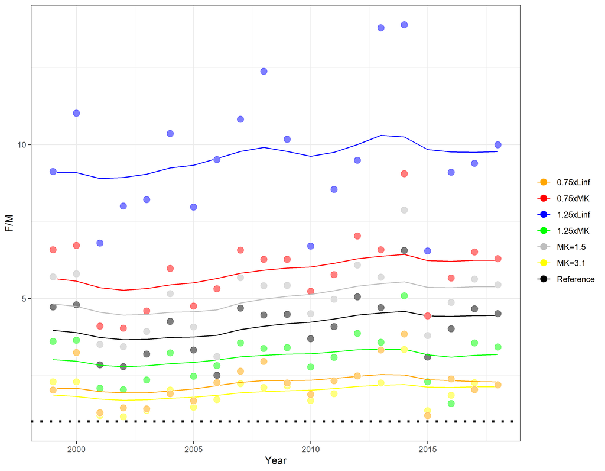

Figure 2. F/M estimates for each of the scenarios of the sensitivity analysis.